# What Drives a Track’s Popularity on Spotify?

### Figure 9. Variable importance with vs. without the artist (share of total)

Importance is shown as each variable’s share of that model’s total, so the two models can be compared on one scale.

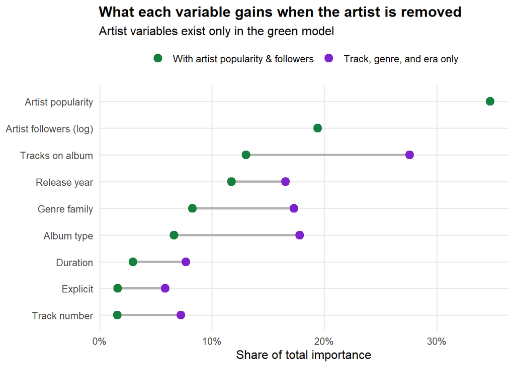

```r
dumb <- imp |>
  group_by(model) |>
  mutate(share = importance / sum(importance)) |>
  ungroup() |>
  mutate(model = factor(model, levels = c("With artist popularity & followers",
                                          "Track, genre, and era only")))

var_order <- dumb |> filter(model == levels(model)[1]) |> arrange(share) |> pull(variable)
dumb <- dumb |> mutate(variable = factor(variable, levels = var_order))

ggplot(dumb, aes(share, variable)) +
  geom_path(aes(group = variable), colour = "grey70", linewidth = 1.2) +
  geom_point(aes(colour = model), size = 3.5) +
  scale_x_continuous(labels = percent_format(accuracy = 1)) +
  scale_colour_manual(values = c(col_main, col_accent), name = NULL) +
  labs(x = "Share of total importance", y = NULL,
       title = "What each variable gains when the artist is removed",
       subtitle = "Artist variables exist only in the green model") +
  theme(legend.position = "top")
```

### Figure 10. Album type by decade

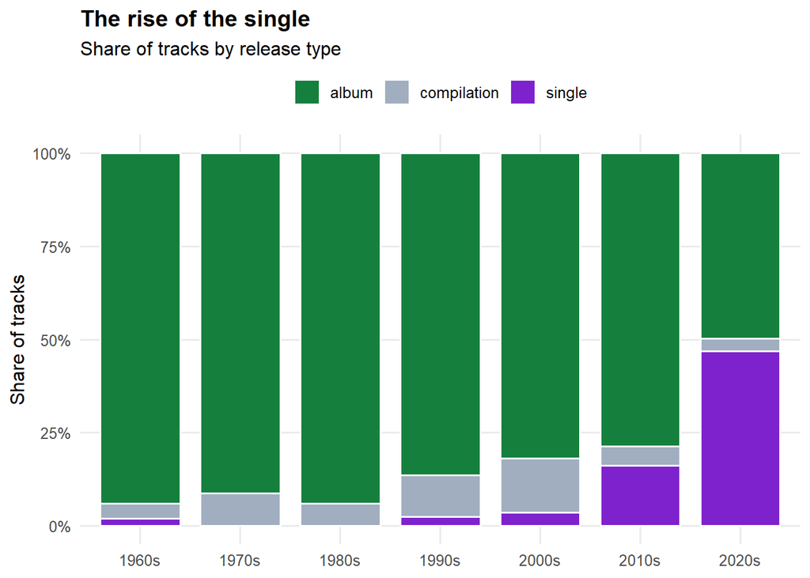

```r
tracks |>
  group_by(decade) |>
  filter(n() >= 25) |>
  ungroup() |>
  count(decade, album_type) |>
  ggplot(aes(decade, n, fill = album_type)) +
  geom_col(position = "fill", colour = "white", linewidth = 0.6, width = 0.8) +
  scale_y_continuous(labels = percent) +
  scale_fill_manual(values = c(album = col_main, single = col_accent, compilation = "#A0AEC0"),
                    name = NULL) +
  labs(x = NULL, y = "Share of tracks",
       title = "The rise of the single",
       subtitle = "Share of tracks by release type") +
  theme(legend.position = "top")
```

### Figure 11. Partial dependence: how predicted popularity changes with year and length

A partial dependence curve shows the model’s average prediction as one variable is varied while all others keep their observed values. A random sample of 400 training tracks is used to keep it fast.

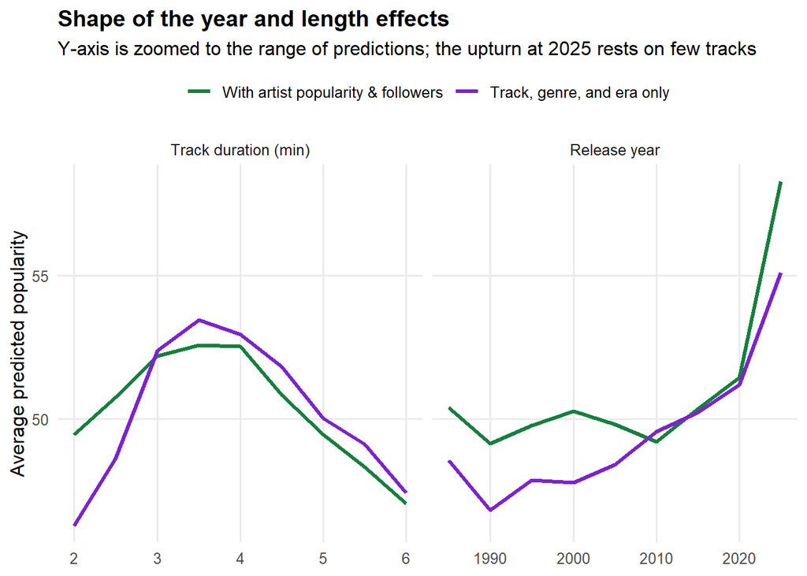

```r
set.seed(607)
pdp_sample <- train |> slice_sample(n = 400)

pdp_curve <- function(model, var, grid, label) {
  tibble(value = grid,
         pred  = map_dbl(grid, function(g) {
           d <- pdp_sample
           d[[var]] <- g
           mean(predict(model, d)$predictions)
         }),
         variable = var, model = label)
}

pdp <- bind_rows(
  pdp_curve(rf_full,  "release_year", seq(1985, 2025, by = 5), "With artist popularity & followers"),
  pdp_curve(rf_track, "release_year", seq(1985, 2025, by = 5), "Track, genre, and era only"),
  pdp_curve(rf_full,  "duration_min", seq(2, 6, by = 0.5),     "With artist popularity & followers"),
  pdp_curve(rf_track, "duration_min", seq(2, 6, by = 0.5),     "Track, genre, and era only")
)

pdp <- pdp |> mutate(model = factor(model, levels = c("With artist popularity & followers",
                                                      "Track, genre, and era only")))

ggplot(pdp, aes(value, pred, colour = model)) +
  geom_line(linewidth = 1.1) +
  facet_wrap(~ variable, scales = "free_x",
             labeller = as_labeller(c(release_year = "Release year",
                                      duration_min = "Track duration (min)"))) +
  scale_colour_manual(values = c(col_main, col_accent), name = NULL) +
  labs(x = NULL, y = "Average predicted popularity",
       title = "Shape of the year and length effects",
       subtitle = "Y-axis is zoomed to the range of predictions; the upturn at 2025 rests on few tracks") +
  theme(legend.position = "top")
```

### Figure 12. Genre bubble chart: length, popularity, size, and explicit share

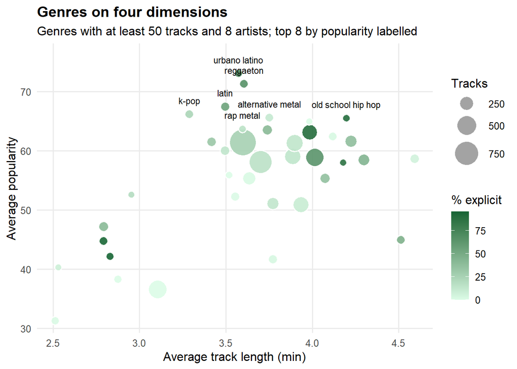

```r
bub <- genre_summary |> filter(Tracks >= 50, Artists >= 8)

ggplot(bub, aes(`Avg length (min)`, `Avg popularity`)) +
  geom_point(aes(size = Tracks, fill = `% explicit`), shape = 21, colour = "white",
             stroke = 0.8, alpha = 0.9) +
  geom_text(data = slice_max(bub, `Avg popularity`, n = 8), aes(label = genre),
            size = 3, vjust = -1.5, check_overlap = TRUE) +
  scale_size_area(max_size = 12, labels = comma,
                  guide = guide_legend(override.aes = list(fill = "grey60"))) +
  scale_y_continuous(expand = expansion(mult = c(0.05, 0.12))) +
  scale_fill_gradient(low = "#DCFCE7", high = "#166534", name = "% explicit") +
  labs(x = "Average track length (min)", y = "Average popularity",
       title = "Genres on four dimensions",
       subtitle = "Genres with at least 50 tracks and 8 artists; top 8 by popularity labelled")
```